# R Notebook

Distributions homework You are given a cut of a database containing details of mobile phones and their customer reviews on an online shopping site in file 20190928-items.csv. Each row in the data corresponds to one model of mobile phone. Use the data to answer the following questions.

As part of the MVP we want you not to just run the code but also have a go at intepreting the results - this is the main learning objective from this homework. Don’t worry if you aren’t sure, it’s ok to get it wrong, but give it a go, through trying we will learn.

1 MVP 1.1 Question 1 Load the data, clean_names() and explore it.

```r
library(tidyverse)
library(janitor)
phones <- read_csv("data/20190928-items.csv") %>%
  # convert prices to numeric
  mutate(prices = as.numeric(str_replace_all(prices, "\\$", ""))) %>%
  clean_names() %>%
  select(asin, title, brand, rating, total_reviews, prices)
```

```
Problem with `mutate()` input `prices`.
ℹ NAs introduced by coercion
ℹ Input `prices` is `as.numeric(str_replace_all(prices, "\\$", ""))`.NAs introduced by coercion
```

```r
# What are the minimum and maximum values for number of reviews?
range(phones$total_reviews)
```

```
[1]   1 984
```

We have phones rated from once to 984 times. We could say that the reviews are more meaningful if they are from a larger number of reviewers.

```r
# How many phones have less than 5 ratings?
phones %>%
  filter(total_reviews < 5)
```

| asin | title | brand | rating | total_reviews | prices |
| --- | --- | --- | --- | --- | --- |
| B001DZY4KI | Sony Ericsson G700 Triband GSM Phone Bronze (Unlocked) | Sony | 2.0 | 1 | 78.99 |
| B001GQ3DJM | Nokia 1680 Black Phone (T-Mobile) | Nokia | 2.7 | 3 | NA |
| B0029X7UHC | Motorola I205 cell phone nextel/Boost | Motorola | 2.9 | 2 | 99.95 |
| B003W646YK | Motorola i570 Nextel iDen PTT rugged black cell phone | Motorola | 2.9 | 3 | 79.00 |
| B0096DERAG | Motorola MC75A Hand Held Computer Windows Mobile 6.5 MC75A8-PYFSWQRA9WR | Motorola | 1.0 | 1 | NA |
| B00B593XAY | Motorola DROID RAZR M, Pink 8GB (Verizon Wireless) | Motorola | 3.2 | 4 | NA |
| B00BIR1LKM | Nokia Lumia 620 Magenta (Factory Unlocked) | Nokia | 3.0 | 2 | 99.99 |
| B00BV1MVJ0 | Samsung Galaxy S4 GT-I9500 Factory Unlocked Cellphone, 16GB, White | Samsung | 3.7 | 1 | 168.96 |
| B00CIF9MJK | Samsung Galaxy S4 i9500 Factory Unlocked Cellphone, International Version, 16GB, Black | Samsung | 3.8 | 1 | 164.92 |
| B00E45043A | Nokia Lumia 520 (AT&T Go Phone) No Annual Contract (Discontinued by Manufacturer) | Nokia | 3.8 | 4 | 84.94 |

[output cut: 129 more lines]

139 of our 792 observations have less than five ratings.

```r
# How many phones have less than 2 ratings?
phones %>%
  filter(total_reviews < 2)
```

| asin | title | brand | rating | total_reviews | prices |
| --- | --- | --- | --- | --- | --- |
| B001DZY4KI | Sony Ericsson G700 Triband GSM Phone Bronze (Unlocked) | Sony | 2.0 | 1 | 78.99 |
| B0096DERAG | Motorola MC75A Hand Held Computer Windows Mobile 6.5 MC75A8-PYFSWQRA9WR | Motorola | 1.0 | 1 | NA |
| B00BV1MVJ0 | Samsung Galaxy S4 GT-I9500 Factory Unlocked Cellphone, 16GB, White | Samsung | 3.7 | 1 | 168.96 |
| B00CIF9MJK | Samsung Galaxy S4 i9500 Factory Unlocked Cellphone, International Version, 16GB, Black | Samsung | 3.8 | 1 | 164.92 |
| B00K0NS0P4 | Motorola Moto G (1st Generation) Unlocked Cellphone, 8GB, White | Motorola | 4.0 | 1 | 209.65 |
| B00K15Q2B0 | Samsung Galaxy S5 G900A 16 GB 4G LTE (Shimmery White) GSM Unlocked | Samsung | 3.2 | 1 | 159.01 |
| B00NKR9FT2 | Samsung Galaxy Note 4, Charcoal Black 32GB (Sprint) | Samsung | 3.4 | 1 | 239.99 |
| B00V7FWBZY | Samsung Galaxy S6, Black Sapphire 32GB (Sprint) | Samsung | 3.5 | 1 | NA |
| B00V7FWPVO | Samsung Galaxy S6, Gold Platinum 64GB (Sprint) | Samsung | 3.5 | 1 | NA |
| B00YD54KJK | Apple iPhone 6 Plus, GSM Unlocked, 64GB - Gold (Renewed) | Apple | 3.2 | 1 | NA |

[output cut: 53 more lines]

63 have less than 2 ratings.

```r
# are there any repeat models in the data?
length(unique(phones$asin))
```

```
[1] 792
```

We have 792 unique asins, which look like a model number, so I don’t think we have any repeated observations.

```r
# check this with phone title
length(unique(phones$title))
```

```
[1] 785
```

We only have 785 unique titles for the phones suggesting 7 overlaps

```r
phones[duplicated(phones$title),]
```

| asin | title | brand | rating | total_reviews | prices |
| --- | --- | --- | --- | --- | --- |
| B014KI1XL2 | Apple iPhone 6, GSM Unlocked, 16GB - Space Gray (Renewed) | Apple | 2.9 | 28 | 104.00 |
| B078YX8S5N | Samsung Galaxy S8 SM-G950U 64GB for T-Mobile (Renewed) | Samsung | 3.0 | 3 | 249.98 |
| B078YXKQSJ | Samsung Galaxy S8 SM-G950U 64GB for AT&T (Renewed) | Samsung | 4.3 | 69 | NA |
| B078YXPCJJ | Samsung Galaxy S8 SM-G950U 64GB for T-Mobile (Renewed) | Samsung | 4.1 | 20 | 247.99 |
| B079J5MKXJ | Google Pixel 2 XL 128GB Unlocked GSM/CDMA 4G LTE Octa-Core Phone w/ 12.2MP Camera - Just Black | Google | 3.7 | 18 | NA |
| B07BSYQ534 | Samsung Galaxy Note 8 SM-N950U 64GB for AT&T (Renewed) | Samsung | 3.6 | 21 | 348.35 |
| B07FMHBMRJ | Samsung Galaxy S7 Edge 32GB SM-G935T Unlocked GSM 4G LTE Android Smartphone (Renewed) | Samsung | 2.0 | 6 | 189.99 |

# Clean instances of these titles, merging the rows by edditing rating as average of the two values and total_reviews as the sum and keeping the asin of the most reviewed one

# Also clean titles using regex to put all models of one phone together, not easy in this dataset.

1.2 Question 2 Find the brand with the highest numbers of phones in the dataset. Samsung has the greatest number of phones in this dataset. 397, compared to 101 by the second greatest, Apple.

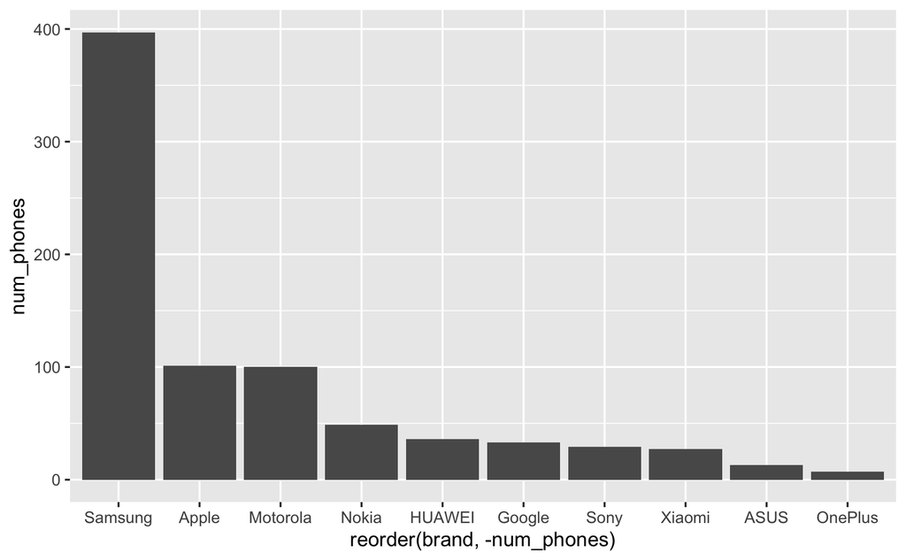

```r
phones %>%
  group_by(brand) %>%
  summarise(num_phones = n()) %>%
  ggplot() +
  aes(x = reorder(brand, -num_phones), y = num_phones) +
  geom_col()
```

```r
top_brand <- phones %>%
  group_by(brand) %>%
  summarise(num_phones = n()) %>%
  arrange(desc(num_phones)) %>%
  head(1) %>%
  pull(brand)
```

1.3 Question 3 For your top brand, plot the distribution of phone ratings as a probability density, overlaying a fitted normal distribution. Do you think the normal distribution provides a good model of these ratings?

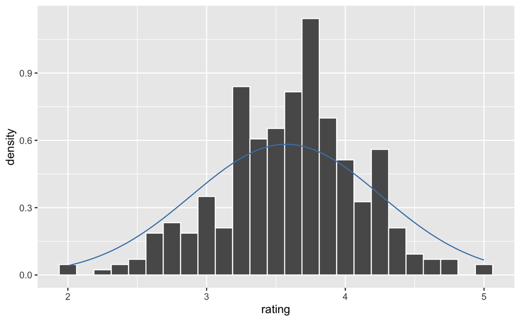

```r
top_brand_phone <- phones %>%
  filter(brand == top_brand)

top_brand_phone_stats <- top_brand_phone %>%
  summarise(n = n(),
            mean = mean(rating),
            sd = sd(rating))

top_brand_phone %>%
 # mutate(binned = cut(rating, breaks = 25)) %>%
  filter(total_reviews > 2) %>%
  ggplot() +
  aes(x = rating) +
  geom_histogram(aes(y = ..density..), col = "white", bins = 25) +
#  geom_smooth(aes(y = ..density..), col = "dark red") +
  stat_function(
    fun = dnorm,
    args = list(
      mean = top_brand_phone_stats$mean,
      sd = top_brand_phone_stats$sd
    ),
    col = "steel blue"
  )
```

1.4 Question 4 We can be more quantitative in comparing the distribution of top brand ratings with a normal distribution. You calculated the mean() and sd() of your distribution in an earlier question. Use these values to calculate the proportions of ratings within one-, two- and three standard deviations of the mean. Compare these proportions with those you expect for a normal distribution.

```r
top_brand_phone %>%
  mutate(
    diff_from_mean = top_brand_phone_stats$mean - rating,
    num_sds = diff_from_mean / top_brand_phone_stats$sd,
    neat_num_sds = case_when(
      between(num_sds, -1, 1) ~ 1,
      between(num_sds, -2, 2) ~ 2,
      between(num_sds, -3, 3) ~ 3
    )
  )%>%
  group_by(neat_num_sds) %>%
  summarise(prop = n() / nrow(top_brand_phone))
```

| neat_num_sds | prop |
| --- | --- |
| 1 | 0.79345088 |
| 2 | 0.12594458 |
| 3 | 0.06045340 |
| NA | 0.02015113 |